# World Band Indicator Visualization

Yizhe Zhang

2020/2/19

## CO2 Emissions by Country

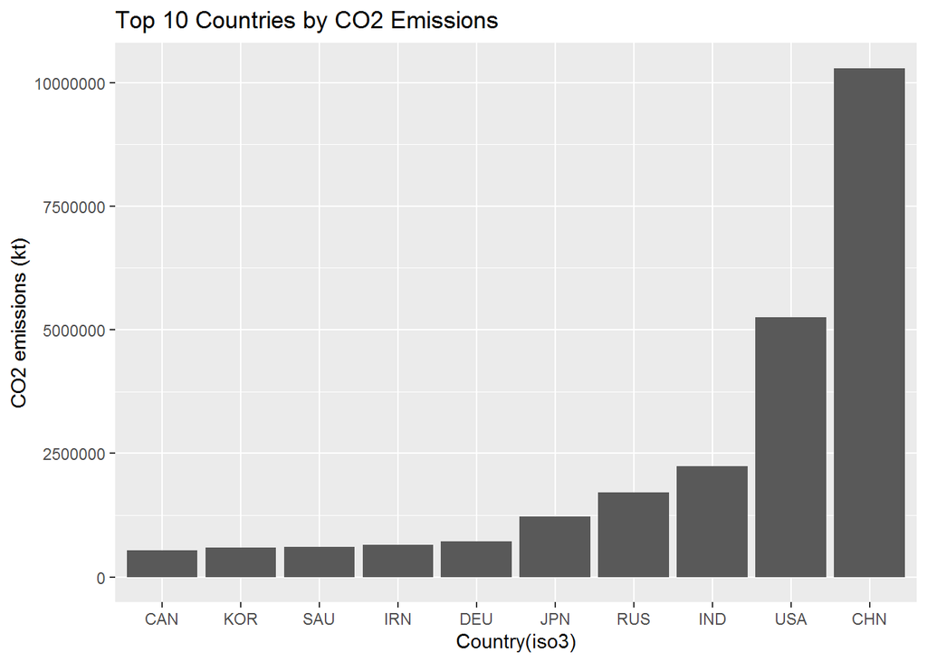

China has the highest CO2 Emission in the world, nearly doubling the number of USA, which has the second highest CO2 Emissions.

## US Income Equality over Time

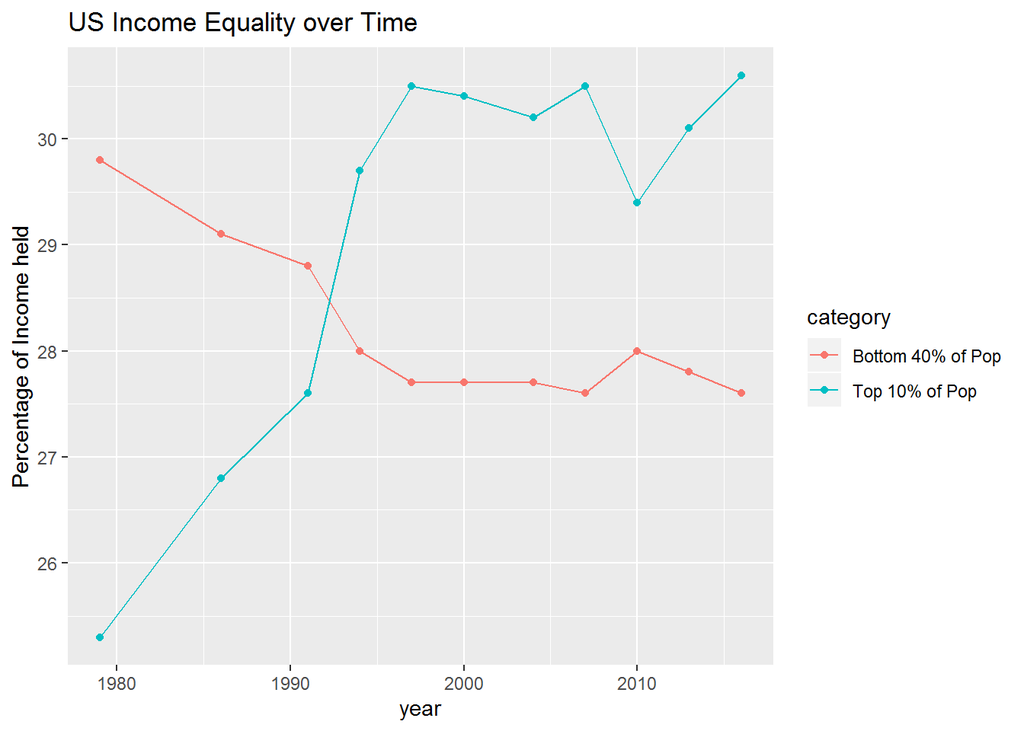

The percentage of income held by the top 10% of the pouplation is higher than the percentage of income held by the bottom 40% of population since mid 1990s.

## Health Expenditures by Country

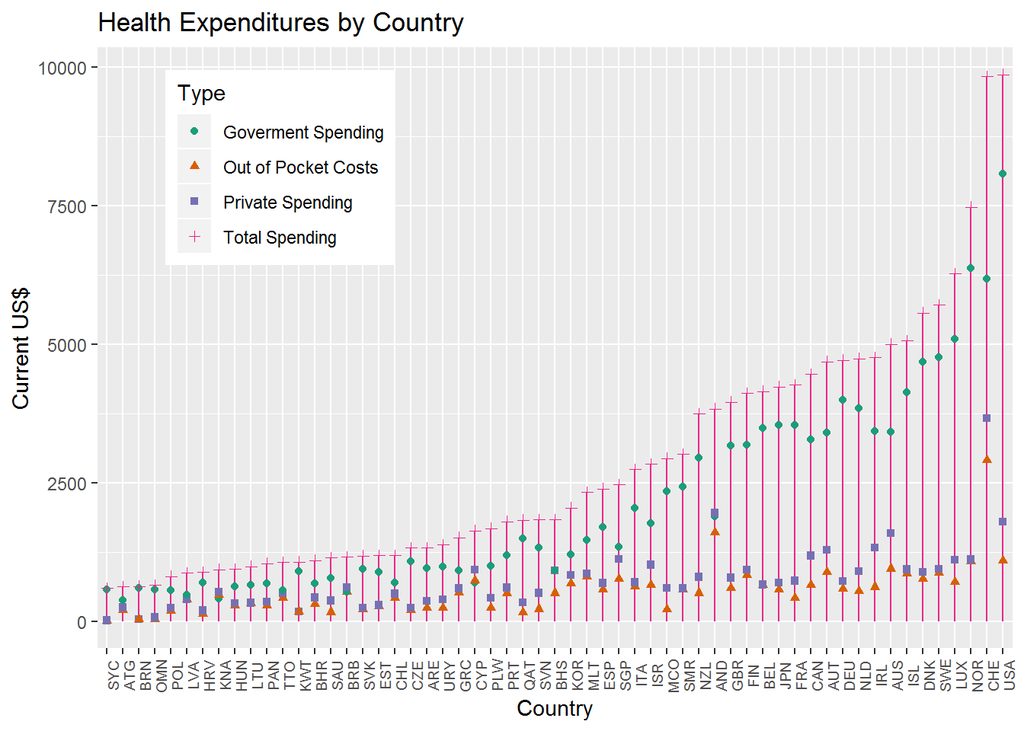

USA has the highest total spending on health care expenditures, with the highest goverment spendin, but the out of pocket spending is rather average.

## Forestation over Time

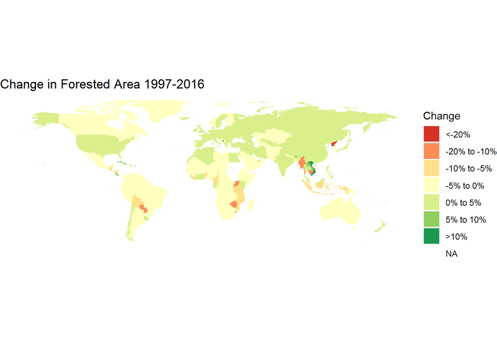

## My Own Plot

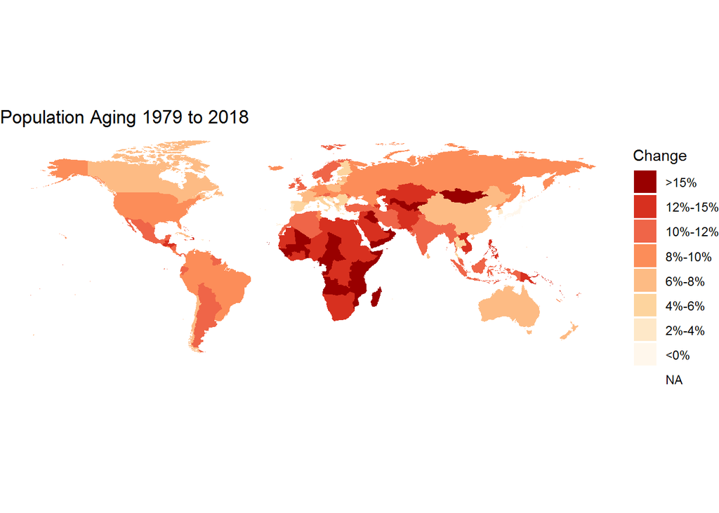

1. My plot is trying to analyze the population aging situation worldwide from 1979 to 2018.
2. The seniors’ percentage of population has increased for than 10% in most areas in Africa.
3. I selected this to compare the different degree of poopulation aging in different countries worldwide.
4. This visualization is effective and expressive for it has very direct colorization associated with the degree of population aging, which is generally considered as a negative thing, which is why I used red.